# ISYE 6402 Homework 8

# Background

We have explored how various U.S. economic indicators are related to each other, which is a classic application for the VAR modeling. In this problem, we will study the inter-dependence and Granger causality between various economic indicators.

# Instructions on reading the data

To read the data in `R`, save the file in your working directory (make sure you have changed the directory if different from the R working directory) and read the data using the `R` function `read.csv()`

```r
rm(list = ls())
# Read the monthly and quarterly data
fname <- file.choose()
data <- read.csv(fname)
fname2 <- file.choose()
data2 <- read.csv(fname2)
date.quarter <- as.Date(data[,1],"%m/%d/%Y")
date.month <- as.Date(data2[,1],"%m/%d/%Y")
```

Here are the libraries you will need:

```r
library(data.table)
library(vars)
library(xts)
library(mgcv)
library(stats)
library(tseries)
library(aod)
library(forecast)
```

# Question 1: Univariate Analysis

## Question 1a

Plot the time series of all indicators for comparison and discuss whether you find any similarities in terms of trend or other features. Plot also the 1st order difference plots and the corresponding ACF plots. Interpret in terms of stationarity and volatility.

Keep in mind, 2 variables have monthly data, while three have quarterly data. You will need to standardise all into quarterly data time series in order to effectively answer all questions below.

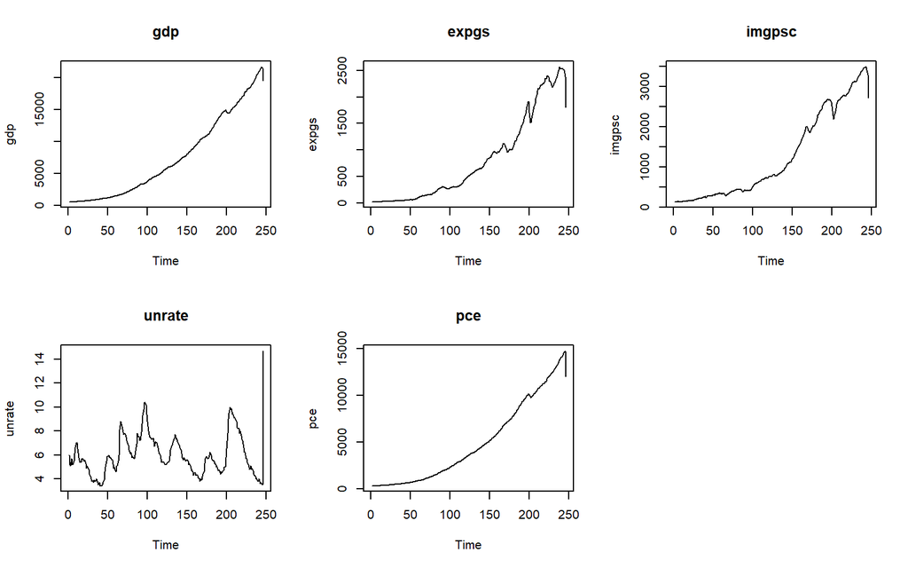

```r
# transform into time series
gdp.ts <- xts(data$GDP, date.quarter)
expgs.ts <- xts(data$EXPGS, date.quarter)
imgpgsc.ts <- xts(data$IMPGSC1, date.quarter)
unrate.ts <- xts(data2$UNRATE, date.month)
pce.ts <- xts(data2$PCE, date.month)
# merge into multivariate time series
ts.merge <- merge(gdp.ts, expgs.ts, join = 'inner')
ts.merge <- merge(ts.merge, imgpgsc.ts, join = 'inner')
ts.merge <- merge(ts.merge, unrate.ts, join = 'inner')
ts.merge <- merge(ts.merge, pce.ts, join = 'inner')
colnames(ts.merge) <- c("tsgdp", "tsexpgs", "tsimgpsc", "tsunrate", "tspce")
#ts.merge

par(mfrow=c(2,3))
ts.plot(ts.merge$tsgdp, ylab="gdp",main="gdp")
ts.plot(ts.merge$tsexpgs, ylab="expgs",main="expgs")
ts.plot(ts.merge$tsimgpsc, ylab="imgpsc",main="imgpsc")
ts.plot(ts.merge$tsunrate, ylab="unrate",main="unrate")
ts.plot(ts.merge$tspce, ylab="pce",main="pce")

dgdp <- diff(ts.merge$tsgdp, start = 1959, frequency = 4)
dexpgs <- diff(ts.merge$tsexpgs, start = 1959, frequency = 4)
dimgpsc <- diff(ts.merge$tsimgpsc, start = 1959, frequency = 4)
dunrate <- diff(ts.merge$tsunrate, start = 1959, frequency = 4)
dpce <- diff(ts.merge$tspce, start = 1959, frequency = 4)

par(mfrow=c(2,3))
```

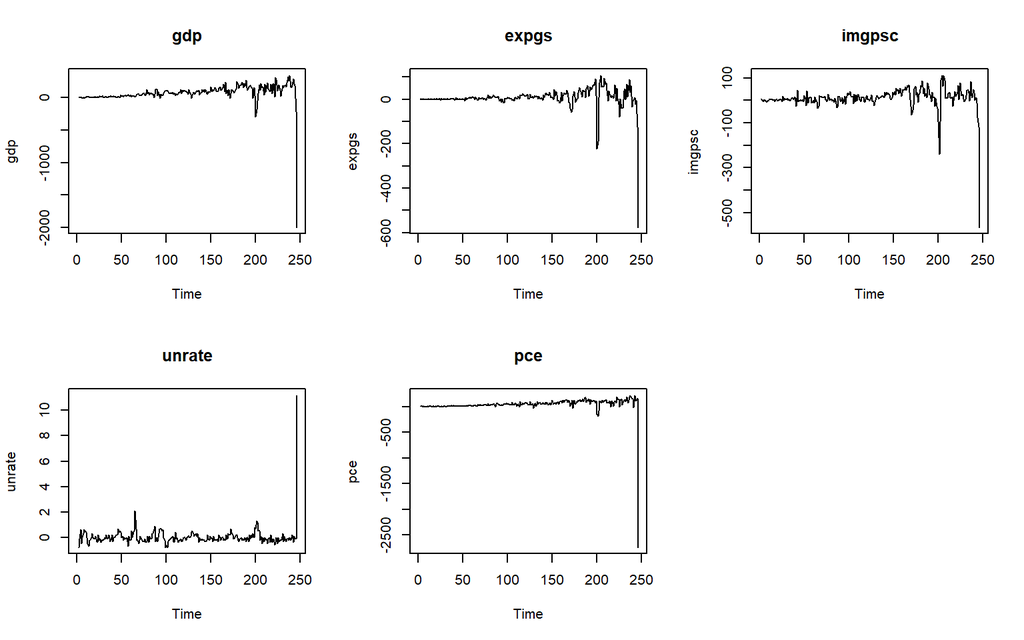

```r
ts.plot(dgdp, ylab="gdp",main="gdp")
ts.plot(dexpgs, ylab="expgs",main="expgs")
ts.plot(dimgpsc, ylab="imgpsc",main="imgpsc")
ts.plot(dunrate, ylab="unrate",main="unrate")
ts.plot(dpce, ylab="pce",main="pce")


################################################################
par(mfrow=c(2,3))
```

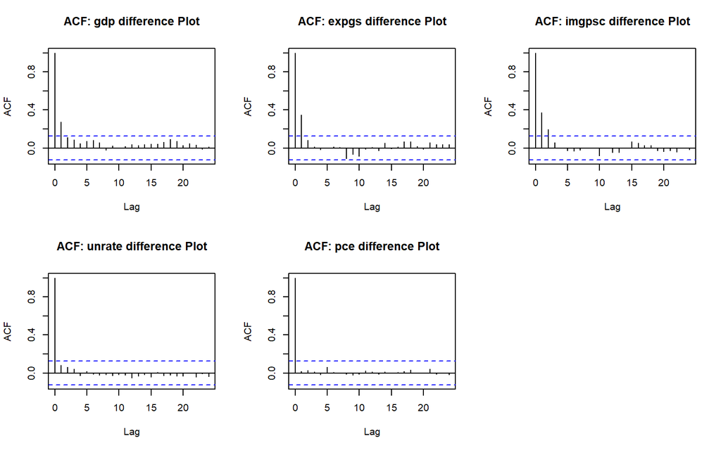

```r
acf(dgdp[-1], lag.max=4*6,main="ACF: gdp difference Plot")
acf(dexpgs[-1],lag.max=4*6,main="ACF: expgs difference Plot")
acf(dimgpsc[-1],lag.max=4*6,main="ACF: imgpsc difference Plot")
acf(dunrate[-1],lag.max=4*6,main="ACF: unrate difference Plot")
acf(dpce[-1],lag.max=4*6,main="ACF: pce difference Plot")
```

*Response*

> *Solution*
- 1. Except for unrate times series, all four time series show similar upward trend and sharp drops in the 2Q of 2020. On the other hand, unrate shows a sharp upward movement.
- 2. 1 order difference removes the trends of four time series data but completely.
- 3. Based on difference plot, volatility is not constant and increasing. And based on acf plot, except for unrate and pce, three time series arn not stationary.

## Question 1b

Using the original, undifferenced data, divide the GDP data into training data including the data for years 1959 to 2019 with the last two quarters being the testing data. Fit the trend using the splines regression to the GDP training time series. Then, apply ARMA to the residuals obtained from this splines fitting. Use max order of 6. Evaluate goodness of fit for the ARMA model. Forecast the first two quarters of 2020 (testing data) and compare to the observed values. Discuss why there are (or not!) significant differences between predicted vs observed. To do this, you should also evaluate the prediction intervals with a 95% confidence level.

```r
n = nrow(ts.merge)
data.train=ts.merge[1:(n-2),]
## Test data: 2016
data.test=ts.merge[(n-1):n,]

time.pt = c(1:nrow(ts.merge))
time.pt = c(time.pt - min(time.pt))/max(time.pt)

#time.pt.train = time.pt[1:(n-2)]
#time.pt.test = time.pt[(n-1):n]
data.total <- data.frame(cbind(ts.merge$tsgdp, time.pt))
#train <- cbind(data.train$tsgdp, time.pt.train)
#test <- cbind(data.test$tsgdp, time.pt.test)
#colnames(test) <- colnames(train)

#gdp.spl<-gam(ts.merge$tsgdp~s(time.pt))
gdp.spl<-gam(tsgdp~s(time.pt), data = data.total[1:244,])
gdp.tsspl<-ts(fitted(gdp.spl),start=1959, freq=4)

gdp.resid = ts.merge[1:244]$tsgdp - gdp.tsspl

norder = 6
p = c(1:norder)-1; q = c(1:norder)-1
aic = matrix(0,norder,norder)
for(i in 1:norder){
   for(j in 1:norder){
    modij = arima(gdp.resid[1:244],order = c(p[i],0,q[j]), method='ML')
    aic[i,j] = modij$aic-2*(p[i]+q[j]+1)+2*(p[i]+q[j]+1)*n/(n-p[i]-q[j]-2)
   }
 }

aicv = as.vector(aic)
#plot(aicv,ylab="AIC values")
indexp = rep(c(1:norder),norder)
indexq = rep(c(1:norder),each=norder)
indexaic = which(aicv == min(aicv))
porder = indexp[indexaic]-1
qorder = indexq[indexaic]-1
print("p-order")
```

```
## [1] "p-order"
```

```r
print(porder)
```

```
## [1] 3
```

```r
print("q-order")
```

```
## [1] "q-order"
```

```r
print(qorder)
```

```
## [1] 1
```

```r
gdp.arma.model = arima(gdp.resid[1:244], order = c(porder,0,qorder), method='ML')

par (mfrow=c(2,3))
plot(resid(gdp.arma.model), ylab='gdp Standardized Residuals')
abline(h=0)
acf(as.vector(resid(gdp.arma.model)),main= 'ACF of the gdp arma Model Residuals')
pacf(as.vector(resid(gdp.arma.model)),main='PACF of the gdp arma Model Residuals')
hist(resid(gdp.arma.model), xlab = 'Residuals', main = 'Histogram of the gdp arma Model Residuals')
qqnorm(resid(gdp.arma.model))
qqline(resid(gdp.arma.model))

pred.spl <- predict.gam(gdp.spl, newdata = data.total[245:246,],se.fit = TRUE)
pred.spl
```

```
## $fit
## 2020-01-01 2020-04-01
##   21809.56   22018.05
##
## $se.fit
## 2020-01-01 2020-04-01
##   61.35313   64.89765
```

```r
pred.arma <- forecast(gdp.arma.model, h=2)
pred_2020 <- pred.spl$fit + as.data.frame(pred.arma)[1]

arma.min1 = pred.spl$fit[1]-1.96*pred.spl$se.fit[1] + pred.arma$lower[2]
arma.max1 = pred.spl$fit[1]+1.96*pred.spl$se.fit[1] + pred.arma$upper[2]
arma.min2 = pred.spl$fit[2]-1.96*pred.spl$se.fit[2] + pred.arma$lower[4]
arma.max2 = pred.spl$fit[2]+1.96*pred.spl$se.fit[2] + pred.arma$upper[4]

com.df1 <- data.frame(pred_2020, data.test$tsgdp, pred_2020$`Point Forecast` - data.test$tsgdp,c(arma.min1,arma.min2), c(arma.max1,arma.max2))
colnames(com.df1) <- c('predicted', "observed", "difference", 'lower 95%', 'upper 95%')
com.df1
```

```
##     predicted observed difference lower 95% upper 95%
## 245  21894.22 21481.37   412.8483  21678.25  22091.86
## 246  22093.55 19477.44  2616.1096  21833.99  22353.12
```

```r
#not significant
```

[figure not shown]

*Response*

> *Solution*
- p and q order are 3 and 1
- Based on residual analysis, the variance is not constant. And ACF and PACF show that residuals are not correlated. And the hostogram looks like normal distribution but based on QQ plot, residuals do not normal distribution. So, this model(trend spline & arma model) is not fitting well.
- The predicted values are 21894.22 and 22093.55. And the observed values are 21481.37 and 19477.44. And the difference are 412.85 and 2616.11.
- **The difference in 2Q of 2020 is quite large.**

  By 1Q of 2020 the trend of gdp was upward, but there was quite significant drop in 2Q of 2020. But the spline model for fitting trend could not capture that drop. It leads to big diffenence between predicted and observed data.

  But, the lower value is also larger than observed value. So, this combination model is not good for predicting the gdp.

## Question 1c

Perform a similar analysis as in (1b) but this time applying ARIMA to the GDP time series training dataset. Compare the forecast and discuss why these are different or similar from the testing data. Assume p,q belong to [0,5] and d belongs to [0,1]. Also evaluate the prediction intervals with a 95% confidence level, and compare the results of the forecast with the analysis in Question 1b.

```r
#d=0
norder = 5
p = c(1:norder)-1; q = c(1:norder)-1
aic1 = matrix(0,norder,norder)
for(i in 1:norder){
   for(j in 1:norder){
     tryCatch(
      expr = {modij = arima(data.train$tsgdp, order = c(p[i],0,q[j]), method='ML')
      #print(modij$aic)
      aic1[i,j] = modij$aic-2*(p[i]+q[j]+1)+2*(p[i]+q[j]+1)*n/(n-p[i]-q[j]-2)},
      error = function(e){aic1[i,j] <<- Inf},
      warning = function(w) {aic1[i,j] <<- Inf}
      )
   }
}
#aic1
aicv1 = as.vector(aic1)
#aicv1
#plot(aicv1,ylab="AIC(d=0) values")
indexp1 = rep(c(1:norder),norder)
indexq1 = rep(c(1:norder),each=norder)
indexaic1 = which(aicv1 == min(aicv1))
porder1 = indexp1[indexaic1]-1
qorder1 = indexq1[indexaic1]-1
#print(porder1)
#print(qorder1)
#print(aicv1[indexaic1])
#aicv1
#d=1
norder = 5
p = c(1:norder)-1; q = c(1:norder)-1
aic2 = matrix(0,norder,norder)
for(i in 1:norder){
   for(j in 1:norder){
    modij = arima(data.train$tsgdp, order = c(p[i],1,q[j]), method='ML')
    aic2[i,j] = modij$aic-2*(p[i]+q[j]+1)+2*(p[i]+q[j]+1)*n/(n-p[i]-q[j]-2)
   }
 }

aicv2 = as.vector(aic2)
#plot(aicv2,ylab="AIC(d=1) values")
indexp2 = rep(c(1:norder),norder)
indexq2 = rep(c(1:norder),each=norder)
indexaic2 = which(aicv2 == min(aicv2))
porder2 = indexp2[indexaic2]-1
qorder2 = indexq2[indexaic2]-1
#print(porder2)
#print(qorder2)
print(aicv1[indexaic2])
```

```
## [1] 2879.873
```

```r
gdp.arima.model = arima(data.train$tsgdp, order = c(2,1,2), method='ML')

pred.arima <- forecast(gdp.arima.model, h=2)

pred.arima
```

```
##     Point Forecast    Lo 80    Hi 80    Lo 95    Hi 95
## 245       21885.52 21815.40 21955.64 21778.28 21992.76
## 246       22072.40 21950.58 22194.22 21886.09 22258.71
```

```r
com.df2 <- data.frame(data.test$tsgdp, pred_2020, as.data.frame(pred.arima)[1], c(pred.arima$lower[2], pred.arima$lower[4]), c(pred.arima$upper[2], pred.arima$upper[4]))
colnames(com.df2) <- c('observed', 'predicted-1b', "predicted-1c", 'lower of arima', 'upper of arima')
com.df2
```

```
##            observed predicted-1b predicted-1c lower of arima upper of arima
## 2020-01-01 21481.37     21894.22     21885.52       21950.58       22194.22
## 2020-04-01 19477.44     22093.55     22072.40       21886.09       22258.71
```

*Response*

# Question 2: Multivariate Analysis using VAR modeling

For this question, divide the quarterly data into training data (excluding the first two quarters of 2020) and testing data (including the two quarters). You will apply the modeling to the training data, and we will forecast the first two quarters of 2020.

## Question 2a

Apply the VAR model to the multivariate time series including all five economic indicators observed quarterly. (Note that you will apply VAR to the training data.) Identify the VAR order using both AIC and BIC and compare. If the selected order using AIC is larger than the selected order than selected using BIC, apply the Wald test to evaluate whether a smaller order than the one selected with AIC would be a better choice, meaning the smaller order model would perform similarly than the larger order model. Interpret the order selection.

This can be done by following the below substeps:- 1)Combine the variables into a multivariate dataset 2)select/display var orders and isolate models using AIC and BIC orders 3)Isolate coefficients and covariances from the AIC model 4)applying the Wald test to the values obtained from the AIC model, but would not be present in the BIC model. You can run a single Wald test for each variable, with all the lagged coefficients for that particular variable, in all resulting in 5 wald tests.

```r
varsel = VARselect(data.train, lag.max = 10, type="both")$selection
varsel
```

```
## AIC(n)  HQ(n)  SC(n) FPE(n)
##      7      2      2      7
```

```r
gdp.var.aic=VAR(data.train, p=7,type="both")
gdp.var.bic=VAR(data.train, p=2,type="both")

## Estimated coefficients and their variance gdp regression Equaltion
coef.gdp = coefficients(gdp.var.aic)$tsgdp[-(7*5+1),1]
var.gdp = vcov(gdp.var.aic)[c(2:(7*5+2)),c(2:(7*5+2))]
wald.test(b=coef.gdp, var.gdp, Terms = seq(11,36))
```

```
## Wald test:
## ----------
##
## Chi-squared test:
## X2 = 39.2, df = 26, P(> X2) = 0.047
```

```r
## Estimated coefficients and their variance expgs regression Equaltion
coef.expgs = coefficients(gdp.var.aic)$tsexpgs[-(7*5+1),1]
var.expgs = vcov(gdp.var.aic)[c(39:74),c(39:74)]
wald.test(b=coef.expgs, var.expgs, Terms = seq(11,36))
```

```
## Wald test:
## ----------
##
## Chi-squared test:
## X2 = 78.9, df = 26, P(> X2) = 3.1e-07
```

```r
## Estimated coefficients and their variance impgsc regression Equaltion
coef.impgsc = coefficients(gdp.var.aic)$tsimgpsc[-(7*5+1),1]
var.impgsc = vcov(gdp.var.aic)[c(76:111),c(76:111)]
wald.test(b=coef.impgsc, var.impgsc, Terms = seq(11,36))
```

```
## Wald test:
## ----------
##
## Chi-squared test:
## X2 = 95.7, df = 26, P(> X2) = 6.5e-10
```

```r
## Estimated coefficients and their variance unrate regression Equaltion
coef.unrate = coefficients(gdp.var.aic)$tsunrate[-(7*5+1),1]
var.unrate = vcov(gdp.var.aic)[c(113:148),c(113:148)]
wald.test(b=coef.unrate, var.unrate, Terms = seq(11,36))
```

```
## Wald test:
## ----------
##
## Chi-squared test:
## X2 = 37.1, df = 26, P(> X2) = 0.073
```

```r
## Estimated coefficients and their variance pce regression Equaltion
coef.pce = coefficients(gdp.var.aic)$tspce[-(7*5+1),1]
var.pce = vcov(gdp.var.aic)[c(150:185),c(150:185)]
wald.test(b=coef.pce, var.pce, Terms = seq(11,36))
```

```
## Wald test:
## ----------
##
## Chi-squared test:
## X2 =  99.9, df = 26, P(> X2) = 1.3e-10
```

*Response*

> *Solution*
- HQ and SC are similar to BIC, generally penalizing more for model complexity than AIC hence selecting lower order models.
- AIC(n) is 7 and HQ(n) or BIC(n) is 2
- **I applied wald-test form order3 to order 7 for each variable.**

  In the 95% confidence level, p-values of wald-test are lower than 0.05 except for unrate. So, null-hypothesis has to be rejected except for unrate and at least one lagged coefficients are not zero.

  In conclusion, the smaller order model would not perform necessarily similar than the larger order model.

## Question 2b

Based on the analysis in 2a, select the VAR order using BIC and fit that model. Print out the model summary and comment on the statistical significance of the coefficients. Apply a model selection analysis using stepwise regression to select the models for each individual time series. What do you conclude from this model selection? Apply the restrict() command in R to restrict the model of order. How do the restricted models compare?

Follow the below steps to implement this: 1)Analyze the coefficients of the unrestricted model. 2)Then treat each of the series separately and do a stepwise regression by apply lm() and step() (in the backward direction with 3 steps) functions to each of the component time series to examine the coefficients 3)The stepwise regressions will return three separate models. Analyze if the same coefficients are significant in the overall VAR versus each of the stepwise models. Discuss. 4)Then build a model using restrict and see which predictors were significant in the restricted VAR model.

```r
summary(gdp.var.bic)
```

```
##
## VAR Estimation Results:
## =========================
## Endogenous variables: tsgdp, tsexpgs, tsimgpsc, tsunrate, tspce
## Deterministic variables: both
## Sample size: 242
## Log Likelihood: -4577.816
## Roots of the characteristic polynomial:
## 1.005 0.9746 0.9746 0.8671 0.8038 0.8038 0.3255 0.3255 0.1654 0.02464
## Call:
## VAR(y = data.train, p = 2, type = "both")
##
##
## Estimation results for equation tsgdp:
## ======================================
## tsgdp = tsgdp.l1 + tsexpgs.l1 + tsimgpsc.l1 + tsunrate.l1 + tspce.l1 + tsgdp.l2 + tsexpgs.l2 + tsimgpsc.l2 + tsunrate.l2 + tspce.l2 + const + trend
##
##              Estimate Std. Error t value Pr(>|t|)
## tsgdp.l1      1.24136    0.08473  14.651  < 2e-16 ***
## tsexpgs.l1   -0.05752    0.15823  -0.364   0.7165
## tsimgpsc.l1   0.60953    0.14457   4.216 3.57e-05 ***
## tsunrate.l1 -13.68038   10.98494  -1.245   0.2143
## tspce.l1     -0.04863    0.12795  -0.380   0.7043
## tsgdp.l2     -0.20262    0.09794  -2.069   0.0397 *
## tsexpgs.l2   -0.02889    0.16097  -0.179   0.8577
## tsimgpsc.l2  -0.62011    0.14673  -4.226 3.43e-05 ***
## tsunrate.l2  15.95778   10.81412   1.476   0.1414
## tspce.l2      0.01984    0.11321   0.175   0.8610
## const        -9.98132   19.44233  -0.513   0.6082
## trend        -0.03454    0.37047  -0.093   0.9258
## ---
## Signif. codes:  0 '***' 0.001 '**' 0.01 '*' 0.05 '.' 0.1 ' ' 1
##
##
## Residual standard error: 51.26 on 230 degrees of freedom
## Multiple R-Squared: 0.9999,  Adjusted R-squared: 0.9999
## F-statistic: 3.283e+05 on 11 and 230 DF,  p-value: < 2.2e-16
##
##
## Estimation results for equation tsexpgs:
```

[output cut: 104 more lines]

```
## Covariance matrix of residuals:
##             tsgdp  tsexpgs tsimgpsc tsunrate    tspce
## tsgdp    2627.934 810.4495  396.237 -2.13845 977.6367
## tsexpgs   810.450 626.4663  243.154 -0.44272 345.2410
## tsimgpsc  396.237 243.1536  612.016 -1.34314 226.8039
## tsunrate   -2.138  -0.4427   -1.343  0.08265  -0.6895
## tspce     977.637 345.2410  226.804 -0.68948 977.8526
##
## Correlation matrix of residuals:
##            tsgdp  tsexpgs tsimgpsc tsunrate   tspce
## tsgdp     1.0000  0.63164   0.3124 -0.14510  0.6099
## tsexpgs   0.6316  1.00000   0.3927 -0.06153  0.4411
## tsimgpsc  0.3124  0.39269   1.0000 -0.18885  0.2932
## tsunrate -0.1451 -0.06153  -0.1889  1.00000 -0.0767
## tspce     0.6099  0.44110   0.2932 -0.07670  1.0000
```

```r
lm.all <- lm(data.train$tsgdp~data.train$tsexpgs+data.train$tsimgpsc+data.train$tsunrate+data.train$tspce)
summary(lm.all)
```

```
##
## Call:
## lm(formula = data.train$tsgdp ~ data.train$tsexpgs + data.train$tsimgpsc +
##     data.train$tsunrate + data.train$tspce)
##
## Residuals:
##     Min      1Q  Median      3Q     Max
## -386.71 -104.62   16.18   85.10  294.57
##
## Coefficients:
##                      Estimate Std. Error t value Pr(>|t|)
## (Intercept)         321.46699   38.59912   8.328 6.40e-15 ***
## data.train$tsexpgs   -0.33943    0.07067  -4.803 2.76e-06 ***
## data.train$tsimgpsc  -0.48867    0.07546  -6.476 5.32e-10 ***
## data.train$tsunrate -15.74939    5.68040  -2.773    0.006 **
## data.train$tspce      1.64958    0.02342  70.449  < 2e-16 ***
## ---
## Signif. codes:  0 '***' 0.001 '**' 0.01 '*' 0.05 '.' 0.1 ' ' 1
##
## Residual standard error: 126.6 on 239 degrees of freedom
## Multiple R-squared:  0.9996, Adjusted R-squared:  0.9996
## F-statistic: 1.494e+05 on 4 and 239 DF,  p-value: < 2.2e-16
```

```r
## Stepwise Regression
full = lm.all
minimum = lm(data.train$tsgdp~1)
step.model <-step(full, k = log(nrow(data.train)), scope = list(lower=minimum, upper = full), steps = 3, direction = "backward")
```

```
## Start:  AIC=2384.92
## data.train$tsgdp ~ data.train$tsexpgs + data.train$tsimgpsc +
##     data.train$tsunrate + data.train$tspce
##
##                       Df Sum of Sq      RSS    AIC
## <none>                              3831565 2384.9
## - data.train$tsunrate  1    123239  3954804 2387.2
## - data.train$tsexpgs   1    369782  4201347 2401.9
## - data.train$tsimgpsc  1    672275  4503841 2418.9
## - data.train$tspce     1  79566756 83398321 3131.0
```

```r
summary(step.model)
```

```
##
## Call:
## lm(formula = data.train$tsgdp ~ data.train$tsexpgs + data.train$tsimgpsc +
##     data.train$tsunrate + data.train$tspce)
##
## Residuals:
##     Min      1Q  Median      3Q     Max
## -386.71 -104.62   16.18   85.10  294.57
##
## Coefficients:
##                      Estimate Std. Error t value Pr(>|t|)
## (Intercept)         321.46699   38.59912   8.328 6.40e-15 ***
## data.train$tsexpgs   -0.33943    0.07067  -4.803 2.76e-06 ***
## data.train$tsimgpsc  -0.48867    0.07546  -6.476 5.32e-10 ***
## data.train$tsunrate -15.74939    5.68040  -2.773    0.006 **
## data.train$tspce      1.64958    0.02342  70.449  < 2e-16 ***
## ---
## Signif. codes:  0 '***' 0.001 '**' 0.01 '*' 0.05 '.' 0.1 ' ' 1
##
## Residual standard error: 126.6 on 239 degrees of freedom
## Multiple R-squared:  0.9996, Adjusted R-squared:  0.9996
## F-statistic: 1.494e+05 on 4 and 239 DF,  p-value: < 2.2e-16
```

```r
#adf.test(step.model$resid)

gdp.var.bic.restrict=restrict(gdp.var.bic)
summary(gdp.var.bic.restrict)
```

```
##
## VAR Estimation Results:
## =========================
## Endogenous variables: tsgdp, tsexpgs, tsimgpsc, tsunrate, tspce
## Deterministic variables: both
## Sample size: 242
## Log Likelihood: -4591.293
## Roots of the characteristic polynomial:
##  1.01 0.9764 0.973 0.973 0.7372 0.7372 0.5089 0.3111 0.1621 0.05873
## Call:
## VAR(y = data.train, p = 2, type = "both")
##
##
## Estimation results for equation tsgdp:
## ======================================
## tsgdp = tsgdp.l1 + tsexpgs.l1 + tsimgpsc.l1 + tsgdp.l2 + tsimgpsc.l2
##
##             Estimate Std. Error t value Pr(>|t|)
## tsgdp.l1     1.26315    0.06356  19.872  < 2e-16 ***
## tsexpgs.l1  -0.09372    0.02277  -4.117 5.31e-05 ***
## tsimgpsc.l1  0.65870    0.12648   5.208 4.14e-07 ***
## tsgdp.l2    -0.24017    0.06469  -3.713 0.000256 ***
## tsimgpsc.l2 -0.68957    0.12694  -5.432 1.38e-07 ***
## ---
## Signif. codes:  0 '***' 0.001 '**' 0.01 '*' 0.05 '.' 0.1 ' ' 1
##
##
## Residual standard error: 50.91 on 237 degrees of freedom
## Multiple R-Squared:     1,   Adjusted R-squared:     1
## F-statistic: 1.756e+06 on 5 and 237 DF,  p-value: < 2.2e-16
##
##
## Estimation results for equation tsexpgs:
## ========================================
## tsexpgs = tsexpgs.l1 + tspce.l1 + tsexpgs.l2 + tspce.l2
##
##            Estimate Std. Error t value Pr(>|t|)
## tsexpgs.l1  1.61201    0.06260  25.751  < 2e-16 ***
## tspce.l1   -0.15459    0.04448  -3.476 0.000606 ***
## tsexpgs.l2 -0.66701    0.06376 -10.462  < 2e-16 ***
```

[output cut: 77 more lines]

```
## Covariance matrix of residuals:
##             tsgdp  tsexpgs tsimgpsc tsunrate    tspce
## tsgdp    2667.624 822.5262  405.909 -2.24272 982.3365
## tsexpgs   822.526 647.9796  249.291 -0.55082 348.7117
## tsimgpsc  405.909 249.2908  617.358 -1.42596 226.7237
## tsunrate   -2.243  -0.5508   -1.426  0.08506  -0.6762
## tspce     982.337 348.7117  226.724 -0.67619 981.7550
##
## Correlation matrix of residuals:
##            tsgdp  tsexpgs tsimgpsc tsunrate    tspce
## tsgdp     1.0000  0.62561   0.3163 -0.14888  0.60701
## tsexpgs   0.6256  1.00000   0.3941 -0.07419  0.43720
## tsimgpsc  0.3163  0.39415   1.0000 -0.19678  0.29122
## tsunrate -0.1489 -0.07419  -0.1968  1.00000 -0.07399
## tspce     0.6070  0.43720   0.2912 -0.07399  1.00000
```

*Response*

> *Solution*
- p order is 2
- **formula for tsgdp**

  formula tsgdp = tsgdp.l1 + tsexpgs.l1 + tsimgpsc.l1 + tsgdp.l2 + tsimgpsc.l2

  restricted var has gdp, expgs and imgpsc as statistical significant variables.

## Question 2c

Evaluate the goodness of fit for the restricted BIC model using the multivariate ARCH test, the Jarque-Bera test and the Portmanteau test. State which assumptions are satisfied, and which are violated. (Note: While we evaluate the residuals for the normality assumption, we do not necessarily assume normality of the data. We use the normality assumption if we use the t-test to evaluate statistical significance.)

```r
arch.test(gdp.var.bic.restrict)
```

```
##
##  ARCH (multivariate)
##
## data:  Residuals of VAR object gdp.var.bic.restrict
## Chi-squared = 2227.2, df = 1125, p-value < 2.2e-16
```

```r
normality.test(gdp.var.bic.restrict)
```

```
## $JB
##
##  JB-Test (multivariate)
##
## data:  Residuals of VAR object gdp.var.bic.restrict
## Chi-squared = 2534.4, df = 10, p-value < 2.2e-16
##
##
## $Skewness
##
##  Skewness only (multivariate)
##
## data:  Residuals of VAR object gdp.var.bic.restrict
## Chi-squared = 135.36, df = 5, p-value < 2.2e-16
##
##
## $Kurtosis
##
##  Kurtosis only (multivariate)
##
## data:  Residuals of VAR object gdp.var.bic.restrict
## Chi-squared = 2399.1, df = 5, p-value < 2.2e-16
```

```r
serial.test(gdp.var.bic.restrict)
```

```
##
##  Portmanteau Test (asymptotic)
##
## data:  Residuals of VAR object gdp.var.bic.restrict
## Chi-squared = 566.25, df = 350, p-value = 1.928e-12
```

*Response* > *Solution*

- **arch-test**

  p-value is smaller than 0 so, null-hypothesis has to be rejected.

  In conclusion, the homoskedasticity assumption is violated.
- **Jarque-Bera test**

  p-value is smaller than 0 so, null-hypothesis has to be rejected.

  In conclusion, the normality assumption is violated.
- **Portmanteau test**

  p-value is smaller than 0 so, null-hypothesis has to be rejected.

  In conclusion, there is statistically significant contemporaneous correlation in the model residuals.

## Question 2d

Using the VAR model with the order selected using BIC, forecast the first two quarters of 2020 using the unrestricted and restricted VAR. Include 95% confidence intervals. Compare the predictions to the observed data. (You don’t need to plot them (but can if you’d like). Using mean absolute percentage error and the precision measure, compare the predictions for GDP derived from the univariate analysis (Question 1) and this multivariate analysis. Discuss on the differences or similarities.

```r
pred.var <- predict(gdp.var.bic, n.ahead=2, ci=0.95)
pred.var.restrict <- predict(gdp.var.bic.restrict, n.ahead=2, ci=0.95)

var.lower <- pred.var$fcst$tsgdp[,'lower']
var.upper <- pred.var$fcst$tsgdp[,'upper']

var.restrict.lower <- pred.var.restrict$fcst$tsgdp[,'lower']
var.restrict.upper <- pred.var.restrict$fcst$tsgdp[,'upper']

var.df <- data.frame(data.test$tsgdp, pred.var$fcst$tsgdp[,1],data.test$tsgdp-pred.var$fcst$tsgdp[,1],  var.lower, var.upper, pred.var.restrict$fcst$tsgdp[,1], data.test$tsgdp-pred.var.restrict$fcst$tsgdp[,1], var.restrict.lower, var.restrict.upper)
colnames(var.df) <- c('observed data', 'var', 'var diff', 'var lower', "var upper",'restriced var', 'restrict var diff', 'restriced var lower', 'restriced var upper' )
var.df
```

```
##            observed data      var   var diff var lower var upper restriced var
## 2020-01-01      21481.37 21841.58  -360.2128  21741.11  21942.05      21845.76
## 2020-04-01      19477.44 22023.74 -2546.2950  21855.64  22191.83      22043.55
##            restrict var diff restriced var lower restriced var upper
## 2020-01-01         -364.3922            21745.98            21945.54
## 2020-04-01        -2566.1080            21874.54            22212.56
```

```r
mape.gdp.var = sum(abs(data.test$tsgdp - pred.var$fcst$tsgdp[,1]) /abs(data.test$tsgdp))/length(data.test$tsgdp)
pm.gdp.var = sum((data.test$tsgdp - pred.var$fcst$tsgdp[,1])^2)/sum((data.test$tsgdp - mean(pred.var$fcst$tsgdp[,1]))^2)

mape.gdp.var.restrict = sum(abs(data.test$tsgdp - pred.var.restrict$fcst$tsgdp[,1]) /abs(data.test$tsgdp))/length(data.test$tsgdp)
pm.gdp.var.restrict = sum((data.test$tsgdp - pred.var.restrict$fcst$tsgdp[,1])^2)/sum((data.test$tsgdp - mean(pred.var.restrict$fcst$tsgdp[,1]))^2)


print("GDP VAR MAPE")
```

```
## [1] "GDP VAR MAPE"
```

```r
mape.gdp.var
```

```
## [1] 0.07374953
```

```r
print("GDP VAR PM")
```

```
## [1] "GDP VAR PM"
```

```r
pm.gdp.var
```

```
## [1] 1.061239
```

```r
print("GDP RESTRICTED VAR MAPE")
```

```
## [1] "GDP RESTRICTED VAR MAPE"
```

```r
mape.gdp.var.restrict
```

```
## [1] 0.07435543
```

```r
print("GDP RESTRICTED VAR PM")
```

```
## [1] "GDP RESTRICTED VAR PM"
```

```r
pm.gdp.var.restrict
```

```
## [1] 1.066001
```

```r
com.df3 <- data.frame(data.test$tsgdp, pred_2020, as.data.frame(pred.arima)[1], pred.var$fcst$tsgdp[,1], pred.var.restrict$fcst$tsgdp[,1])
colnames(com.df3) <- c('observed data', 'spline+arma', "arima", 'var', 'restriced var')
com.df3
```

```
##            observed data spline+arma    arima      var restriced var
## 2020-01-01      21481.37    21894.22 21885.52 21841.58      21845.76
## 2020-04-01      19477.44    22093.55 22072.40 22023.74      22043.55
```

*Response*

  But, the lower values are also larger than observed value. So, these two models are not good for predicting the gdp.
- **“GDP VAR MAPE” is 0.07374953, “GDP VAR PM” is 1.061239, “GDP RESTRICTED VAR MAPE” is 0.07435543 and “GDP RESTRICTED VAR PM” is 1.066001**

  Based on MAPE and PM, the performances are similar between two models.
- Comparing to two univariate models in Question 1, predicted values of var and var-restrict model are smaller and close to observed data. but the differences are not significantly large.

## Question 2e

Perform a Granger Causality analysis using Wald test to evaluate whether any of the economic indicators lead GDP. Would any of the indicators help in predicting or explaining GDP for next quarters? Provide your interpretation based on the Granger causality as well as for forecasting comparison in (2d).For this, use the unrestricted bic model from Question 2a.

```r
## Estimated coefficients and their variance gdp regression Equaltion
coef.gdp.bic = coefficients(gdp.var.bic)$tsgdp[-(2*5+1),1]
var.gdp.bic = vcov(gdp.var.bic)[c(2:(2*5+2)),c(2:(2*5+2))]

# wald test for expgs
wald.test(b=coef.gdp.bic, var.gdp.bic, Terms = seq(2,7))
```

```
## Wald test:
## ----------
##
## Chi-squared test:
## X2 = 53.9, df = 6, P(> X2) = 7.6e-10
```

```r
# wald test for imgpsc
wald.test(b=coef.gdp.bic, var.gdp.bic, Terms = seq(3,8))
```

```
## Wald test:
## ----------
##
## Chi-squared test:
## X2 = 47.5, df = 6, P(> X2) = 1.5e-08
```

```r
# wald test for unrate
wald.test(b=coef.gdp.bic, var.gdp.bic, Terms = seq(4,9))
```

```
## Wald test:
## ----------
##
## Chi-squared test:
## X2 = 55.4, df = 6, P(> X2) = 3.9e-10
```

```r
# wald test for pce
wald.test(b=coef.gdp.bic, var.gdp.bic, Terms = seq(5,10))
```

```
## Wald test:
## ----------
##
## Chi-squared test:
## X2 = 85.9, df = 6, P(> X2) = 2.2e-16
```

*Response*

> *solution*
- p-values of 4 Wald test are smaller than 0 so, null-hypothesis has to be rejected.
- Comparing to two univariate models in Question 1, predicted values of var and var-restrict model are smaller and close to observed data but the differences are not significantly large.
- In conclusion, based on Wald test all variables help in predicting or explaining GDP for next quarters but based on results of prediction, all variables are not necessarily helpful in predicting or explaining GDP for next quarters.

# Question 3

For this question, consider the training data to include the time values up to December 2017 and the testing data to include the first two quarters of 2018.

## Question 3a

Apply the VAR modeling approach with the order selected using the BIC approach giving the unrestricted VAR model. Apply a model selection analysis using stepwise regression to select the models for each individual time series. Based on the selected models, form the restricted VAR model, much like what was presented in the Moose R example code. Compare these two models in terms of coefficients and their statistical significance with the models derived in Question 2.

Follow the below steps to implement this: 1)Analyze the coefficients of the unrestricted model. 2)Then treat each of the series separately and do a stepwise regression by apply lm() and step()(in the backward direction with 3 steps) functions to each of the component time series to examine the coefficients 3)The stepwise regressions will return three separate models. Analyze if the same coefficients are significant in the overall VAR versus each of the stepwise models. Discuss. 4)Then build a model using restrict and see which predictors were significant in the restricted VAR model.

```r
data.train.part=ts.merge[1:236,]
## Test data: 2016
data.test.part=ts.merge[237:238,]

varsel.part = VARselect(data.train.part, lag.max = 10, type="both")$selection
varsel.part
```

```
## AIC(n)  HQ(n)  SC(n) FPE(n)
##      5      2      2      5
```

```r
gdp.var.part.bic=VAR(data.train.part, p=2,type="both", ic='BIC')

summary(gdp.var.part.bic)
```

```
##
## VAR Estimation Results:
## =========================
## Endogenous variables: tsgdp, tsexpgs, tsimgpsc, tsunrate, tspce
## Deterministic variables: both
## Sample size: 234
## Log Likelihood: -4378.462
## Roots of the characteristic polynomial:
## 0.9977 0.9662 0.9662 0.8784 0.8064 0.8064 0.3046 0.3046 0.1231 0.1231
## Call:
## VAR(y = data.train.part, p = 2, type = "both", ic = "BIC")
##
##
## Estimation results for equation tsgdp:
## ======================================
## tsgdp = tsgdp.l1 + tsexpgs.l1 + tsimgpsc.l1 + tsunrate.l1 + tspce.l1 + tsgdp.l2 + tsexpgs.l2 + tsimgpsc.l2 + tsunrate.l2 + tspce.l2 + const + trend
##
##               Estimate Std. Error t value Pr(>|t|)
## tsgdp.l1      1.192843   0.088041  13.549  < 2e-16 ***
## tsexpgs.l1   -0.051152   0.161190  -0.317   0.7513
## tsimgpsc.l1   0.656164   0.146421   4.481 1.19e-05 ***
## tsunrate.l1 -14.688170  10.821480  -1.357   0.1761
## tspce.l1     -0.026116   0.137232  -0.190   0.8492
## tsgdp.l2     -0.169552   0.098907  -1.714   0.0879 .
## tsexpgs.l2   -0.027696   0.162985  -0.170   0.8652
## tsimgpsc.l2  -0.648142   0.147359  -4.398 1.69e-05 ***
## tsunrate.l2  17.743849  10.707745   1.657   0.0989 .
## tspce.l2      0.009632   0.120863   0.080   0.9366
## const       -19.175047  20.003304  -0.959   0.3388
## trend         0.205231   0.388182   0.529   0.5975
## ---
## Signif. codes:  0 '***' 0.001 '**' 0.01 '*' 0.05 '.' 0.1 ' ' 1
##
##
## Residual standard error: 50.26 on 222 degrees of freedom
## Multiple R-Squared: 0.9999,  Adjusted R-squared: 0.9999
## F-statistic: 2.868e+05 on 11 and 222 DF,  p-value: < 2.2e-16
##
##
## Estimation results for equation tsexpgs:
```

[output cut: 104 more lines]

```
## Covariance matrix of residuals:
##             tsgdp  tsexpgs tsimgpsc tsunrate    tspce
## tsgdp    2526.058 811.8299  452.435 -2.11162 940.0610
## tsexpgs   811.830 601.2676  239.155 -0.49819 347.6302
## tsimgpsc  452.435 239.1553  551.753 -1.31758 251.1082
## tsunrate   -2.112  -0.4982   -1.318  0.08392  -0.6967
## tspce     940.061 347.6302  251.108 -0.69674 891.7610
##
## Correlation matrix of residuals:
##            tsgdp  tsexpgs tsimgpsc tsunrate    tspce
## tsgdp     1.0000  0.65873   0.3832 -0.14503  0.62634
## tsexpgs   0.6587  1.00000   0.4152 -0.07013  0.47474
## tsimgpsc  0.3832  0.41522   1.0000 -0.19363  0.35798
## tsunrate -0.1450 -0.07013  -0.1936  1.00000 -0.08054
## tspce     0.6263  0.47474   0.3580 -0.08054  1.00000
```

```r
lm.part <- lm(data.train.part$tsgdp~data.train.part$tsexpgs+data.train.part$tsimgpsc+data.train.part$tsunrate+data.train.part$tspce)
summary(lm.part)
```

```
##
## Call:
## lm(formula = data.train.part$tsgdp ~ data.train.part$tsexpgs +
##     data.train.part$tsimgpsc + data.train.part$tsunrate + data.train.part$tspce)
##
## Residuals:
##     Min      1Q  Median      3Q     Max
## -405.25 -106.84   23.76   85.14  288.37
##
## Coefficients:
##                           Estimate Std. Error t value Pr(>|t|)
## (Intercept)              351.71749   40.76992   8.627 1.03e-15 ***
## data.train.part$tsexpgs   -0.33952    0.07123  -4.767 3.31e-06 ***
## data.train.part$tsimgpsc  -0.55848    0.08117  -6.880 5.57e-11 ***
## data.train.part$tsunrate -21.40904    6.17940  -3.465 0.000633 ***
## data.train.part$tspce      1.66902    0.02490  67.037  < 2e-16 ***
## ---
## Signif. codes:  0 '***' 0.001 '**' 0.01 '*' 0.05 '.' 0.1 ' ' 1
##
## Residual standard error: 126.8 on 231 degrees of freedom
## Multiple R-squared:  0.9995, Adjusted R-squared:  0.9995
## F-statistic: 1.251e+05 on 4 and 231 DF,  p-value: < 2.2e-16
```

```r
## Stepwise Regression
full.part = lm.part
minimum.part = lm(data.train.part$tsgdp~1)
step.model.part <-step(full.part, k = log(nrow(data.train.part)), scope = list(lower=minimum.part, upper = full.part), steps = 3, direction = "backward")
```

```
## Start:  AIC=2307.97
## data.train.part$tsgdp ~ data.train.part$tsexpgs + data.train.part$tsimgpsc +
##     data.train.part$tsunrate + data.train.part$tspce
##
##                            Df Sum of Sq      RSS    AIC
## <none>                                   3713992 2308.0
## - data.train.part$tsunrate  1    192988  3906980 2314.5
## - data.train.part$tsexpgs   1    365317  4079309 2324.7
## - data.train.part$tsimgpsc  1    761030  4475021 2346.5
## - data.train.part$tspce     1  72252327 75966319 3014.8
```

```r
summary(step.model.part)
```

```
##
## Call:
## lm(formula = data.train.part$tsgdp ~ data.train.part$tsexpgs +
##     data.train.part$tsimgpsc + data.train.part$tsunrate + data.train.part$tspce)
##
## Residuals:
##     Min      1Q  Median      3Q     Max
## -405.25 -106.84   23.76   85.14  288.37
##
## Coefficients:
##                           Estimate Std. Error t value Pr(>|t|)
## (Intercept)              351.71749   40.76992   8.627 1.03e-15 ***
## data.train.part$tsexpgs   -0.33952    0.07123  -4.767 3.31e-06 ***
## data.train.part$tsimgpsc  -0.55848    0.08117  -6.880 5.57e-11 ***
## data.train.part$tsunrate -21.40904    6.17940  -3.465 0.000633 ***
## data.train.part$tspce      1.66902    0.02490  67.037  < 2e-16 ***
## ---
## Signif. codes:  0 '***' 0.001 '**' 0.01 '*' 0.05 '.' 0.1 ' ' 1
##
## Residual standard error: 126.8 on 231 degrees of freedom
## Multiple R-squared:  0.9995, Adjusted R-squared:  0.9995
## F-statistic: 1.251e+05 on 4 and 231 DF,  p-value: < 2.2e-16
```

```r
#adf.test(step.model.part$resid)

gdp.var.bic.part.restrict=restrict(gdp.var.part.bic)
summary(gdp.var.bic.part.restrict)
```

```
##
## VAR Estimation Results:
## =========================
## Endogenous variables: tsgdp, tsexpgs, tsimgpsc, tsunrate, tspce
## Deterministic variables: both
## Sample size: 234
## Log Likelihood: -4394.363
## Roots of the characteristic polynomial:
## 1.005 0.9771 0.9771 0.9735 0.779 0.779  0.38 0.2052 0.09325 0.09325
## Call:
## VAR(y = data.train.part, p = 2, type = "both", ic = "BIC")
##
##
## Estimation results for equation tsgdp:
## ======================================
## tsgdp = tsgdp.l1 + tsexpgs.l1 + tsimgpsc.l1 + tsgdp.l2 + tsimgpsc.l2
##
##             Estimate Std. Error t value Pr(>|t|)
## tsgdp.l1     1.25095    0.06583  19.003  < 2e-16 ***
## tsexpgs.l1  -0.09800    0.02297  -4.266 2.92e-05 ***
## tsimgpsc.l1  0.69062    0.12881   5.361 2.01e-07 ***
## tsgdp.l2    -0.22777    0.06697  -3.401 0.000792 ***
## tsimgpsc.l2 -0.72016    0.12878  -5.592 6.36e-08 ***
## ---
## Signif. codes:  0 '***' 0.001 '**' 0.01 '*' 0.05 '.' 0.1 ' ' 1
##
##
## Residual standard error: 50.15 on 229 degrees of freedom
## Multiple R-Squared:     1,   Adjusted R-squared:     1
## F-statistic: 1.53e+06 on 5 and 229 DF,  p-value: < 2.2e-16
##
##
## Estimation results for equation tsexpgs:
## ========================================
## tsexpgs = tsgdp.l1 + tsexpgs.l1 + tspce.l1 + tsgdp.l2 + tsexpgs.l2 + tspce.l2
##
##            Estimate Std. Error t value Pr(>|t|)
## tsgdp.l1    0.08929    0.04038   2.211 0.028020 *
## tsexpgs.l1  1.55758    0.07387  21.084  < 2e-16 ***
## tspce.l1   -0.20418    0.05947  -3.433 0.000709 ***
```

[output cut: 79 more lines]

```
## Covariance matrix of residuals:
##             tsgdp  tsexpgs tsimgpsc tsunrate    tspce
## tsgdp    2589.643 820.3066  452.310 -2.23223 946.3442
## tsexpgs   820.307 615.0514  236.833 -0.54180 350.2402
## tsimgpsc  452.310 236.8327  559.984 -1.25711 250.5160
## tsunrate   -2.232  -0.5418   -1.257  0.08555  -0.6824
## tspce     946.344 350.2402  250.516 -0.68240 896.7575
##
## Correlation matrix of residuals:
##            tsgdp  tsexpgs tsimgpsc tsunrate    tspce
## tsgdp     1.0000  0.64998   0.3756 -0.14997  0.62100
## tsexpgs   0.6500  1.00000   0.4036 -0.07469  0.47160
## tsimgpsc  0.3756  0.40355   1.0000 -0.18162  0.35352
## tsunrate -0.1500 -0.07469  -0.1816  1.00000 -0.07791
## tspce     0.6210  0.47160   0.3535 -0.07791  1.00000
```

*Response*

> *Solution*
- p order is 2 based on BIC
- **formula for tsgdp**

  tsgdp = tsgdp.l1 + tsexpgs.l1 + tsimgpsc.l1 + tsunrate.l1 + tspce.l1 + tsgdp.l2 + tsexpgs.l2 + tsimgpsc.l2 + tsunrate.l2 + tspce.l2 + const + trend
- In the 95% confidence level, tsgdp.l1, tsimgpsc.l1, and tsimgpsc.l2 are statistical significant.
- **stepwise method**

  With backward and BIC, step.model choose all features and all coefficients of step.model are statistical significant in the 95% confidence level.
- Unrestricted model has gdp, imgpsc and imgpsc as statistical significant variables but step model has all variables as statistical significant variables.
- **restricted var**

  formula tsgdp = tsgdp.l1 + tsexpgs.l1 + tsimgpsc.l1 + tsgdp.l2 + tsimgpsc.l2

  restricted var has gdp, expgs and imgpsc as statistical significant variables.

## Question 3b

Forecast the first two quarters of 2018 using the unrestricted and restricted VAR models derived in (3a). Include 95% confidence intervals. Compare the predictions to the observed data using mean absolute percentage error and the precision measure for GDP. Compare the predictions to those derived in (2d). Comment on the accuracy of the predictions.

```r
pred.var.part <- predict(gdp.var.part.bic, n.ahead=2)
pred.var.part.restrict <- predict(gdp.var.bic.part.restrict, n.ahead=2)

var.part.lower <- pred.var.part$fcst$tsgdp[,'lower']
var.part.upper <- pred.var.part$fcst$tsgdp[,'upper']

var.restrict.part.lower <- pred.var.part.restrict$fcst$tsgdp[,'lower']
var.restrict.part.upper <- pred.var.part.restrict$fcst$tsgdp[,'upper']

var.part.df <- data.frame(data.test.part$tsgdp, pred.var.part$fcst$tsgdp[,1],data.test.part$tsgdp-pred.var.part$fcst$tsgdp[,1], var.part.lower, var.part.upper, pred.var.part.restrict$fcst$tsgdp[,1], data.test.part$tsgdp-pred.var.part.restrict$fcst$tsgdp[,1], var.restrict.part.lower, var.restrict.part.upper)

colnames(var.part.df) <- c('observed data', 'var.part', 'var.part diff', 'var.part lower', "var.part upper",'restriced var.part', 'restrict var.part diff', 'restriced var.part lower', 'restriced var.part upper' )
var.part.df
```

```
##            observed data var.part var.part diff var.part lower var.part upper
## 2018-01-01      20143.72 20111.56      32.15758       20013.05       20210.07
## 2018-04-01      20492.49 20329.18     163.31641       20165.16       20493.19
##            restriced var.part restrict var.part diff restriced var.part lower
## 2018-01-01           20137.19               6.529222                 20038.90
## 2018-04-01           20376.01             116.477862                 20209.12
##            restriced var.part upper
## 2018-01-01                 20235.47
## 2018-04-01                 20542.91
```

```r
mape.gdp.var.part = sum(abs(data.test.part$tsgdp - pred.var.part$fcst$tsgdp[,1]) /abs(data.test.part$tsgdp))/length(data.test.part$tsgdp)
pm.gdp.var.part = sum((data.test.part$tsgdp - pred.var.part$fcst$tsgdp[,1])^2)/sum((data.test.part$tsgdp - mean(pred.var.part$fcst$tsgdp[,1]))^2)

mape.gdp.var.part.restrict = sum(abs(data.test.part$tsgdp - pred.var.part.restrict$fcst$tsgdp[,1]) /abs(data.test.part$tsgdp))/length(data.test.part$tsgdp)
pm.gdp.var.part.restrict = sum((data.test.part$tsgdp - pred.var.part.restrict$fcst$tsgdp[,1])^2)/sum((data.test.part$tsgdp - mean(pred.var.part.restrict$fcst$tsgdp[,1]))^2)


print("GDP PART VAR MAPE")
```

```
## [1] "GDP PART VAR MAPE"
```

```r
mape.gdp.var.part
```

```
## [1] 0.00478299
```

```r
print("GDP PART VAR PM")
```

```
## [1] "GDP PART VAR PM"
```

```r
pm.gdp.var.part
```

```
## [1] 0.3466441
```

```r
print("GDP PART RESTRICTED VAR MAPE")
```

```
## [1] "GDP PART RESTRICTED VAR MAPE"
```

```r
mape.gdp.var.part.restrict
```

```
## [1] 0.00300403
```

```r
print("GDP PART RESTRICTED VAR PM")
```

```
## [1] "GDP PART RESTRICTED VAR PM"
```

```r
pm.gdp.var.part.restrict
```

```
## [1] 0.1990083
```

```r
#print("**************************************")
#print("GDP VAR MAPE")
#mape.gdp.var
#print("GDP VAR PM")
#pm.gdp.var
#print("GDP RESTRICTED VAR MAPE")
#mape.gdp.var.restrict
#print("GDP RESTRICTED VAR PM")
#pm.gdp.var.restrict

com.df4 <- data.frame(data.test$tsgdp, pred.var$fcst$tsgdp[,1],data.test$tsgdp-pred.var$fcst$tsgdp[,1], pred.var.restrict$fcst$tsgdp[,1], data.test$tsgdp-pred.var.restrict$fcst$tsgdp[,1],data.test.part$tsgdp, pred.var.part$fcst$tsgdp[,1],data.test.part$tsgdp-pred.var.part$fcst$tsgdp[,1], pred.var.part.restrict$fcst$tsgdp[,1], data.test.part$tsgdp-pred.var.part.restrict$fcst$tsgdp[,1])
colnames(com.df4) <- c('2020 observed data','var20', 'var20 diff', 'restriced var20','restrict var20diff', '2018 observed data','var18', 'var18 diff', 'restriced var18','restrict var18 diff')
com.df4
```

```
##            2020 observed data    var20 var20 diff restriced var20
## 2020-01-01           21481.37 21841.58  -360.2128        21845.76
## 2020-04-01           19477.44 22023.74 -2546.2950        22043.55
##            restrict var20diff 2018 observed data    var18 var18 diff
## 2020-01-01          -364.3922           20143.72 20111.56   32.15758
## 2020-04-01         -2566.1080           20492.49 20329.18  163.31641
##            restriced var18 restrict var18 diff
## 2020-01-01        20137.19            6.529222
## 2020-04-01        20376.01          116.477862
```

*Response*

> *Solution*
- (var model) The predicted values are 20111.56 and 20329.18. And the observed values are 20143.72 and 20492.49. And the difference are 32.16 and 163.32.
- (var restrice model) The predicted values are 20137.19 and 20376.01. And the observed values are 20143.72 and 20492.49. And the difference are 6.53 and 116.48.
- **Two predicted values are between the prediction intervals with a 95% confidence level. So, the predicted values are not significantly different from observed values.**

  And, observed values are between lower and upper values. So, these two models are good for predicting the gdp.
- **“GDP PART VAR MAPE” is 0.00478299, “GDP PART VAR PM” is 0.3466441, “GDP PART RESTRICTED VAR MAPE” is 0.00300403 and “GDP PART RESTRICTED VAR PM” is 0.1990083,**

  Based on MAPE and PM, the restricted var model is better.
- **Comparing to two var and restricted var models that are predicting GDP in 2020, predicted values of var and var-restrict model that are predicting gdp of 2108 are very close to observed data. but the differences are not significantly small.**

  Because gdp time series shows stable upward trend by 2019 year but they drop sharply in the 2Q of 2020. So, the two var and restricted var models that are using full data for training would not capture the sharp drop.

## Question 3c

Perform a Granger Causality analysis using Wald test to evaluate whether any of the economic indicators lead GDP. Would any of the indicators help in predicting or explaining GDP for next quarters? Provide your interpretation based on the Granger causality as well as for forecasting comparison in (3b). Compare this analysis with the findings in (2e). For this question, use the unrestricted VAR model from Question 3a.

```r
## Estimated coefficients and their variance gdp regression Equaltion
coef.gdp.bic.part = coefficients(gdp.var.part.bic)$tsgdp[-(2*5+1),1]
var.gdp.bic.part = vcov(gdp.var.part.bic)[c(2:(2*5+2)),c(2:(2*5+2))]

# wald test for expgs
wald.test(b=coef.gdp.bic.part, var.gdp.bic.part, Terms = seq(2,7))
```

```
## Wald test:
## ----------
##
## Chi-squared test:
## X2 = 56.5, df = 6, P(> X2) = 2.3e-10
```

```r
# wald test for imgpsc
wald.test(b=coef.gdp.bic.part, var.gdp.bic.part, Terms = seq(3,8))
```

```
## Wald test:
## ----------
##
## Chi-squared test:
## X2 = 50.8, df = 6, P(> X2) = 3.2e-09
```

```r
# wald test for unrate
wald.test(b=coef.gdp.bic.part, var.gdp.bic.part, Terms = seq(4,9))
```

```
## Wald test:
## ----------
##
## Chi-squared test:
## X2 = 59.2, df = 6, P(> X2) = 6.4e-11
```

```r
# wald test for pce
wald.test(b=coef.gdp.bic.part, var.gdp.bic.part, Terms = seq(5,10))
```

```
## Wald test:
## ----------
##
## Chi-squared test:
## X2 = 83.6, df = 6, P(> X2) = 6.7e-16
```

*Response*

> *solution*
- p-values of 4 Wald test are smaller than 0 so, null-hypothesis has to be rejected.
- Comparing to two var and restricted var models in Question2d, predicted values of var and var-restrict model in Question3b are smaller and close to observed data and the differences are significantly large.
- In conclusion, based on Wald test and results of prediction, all variables help in predicting or explaining GDP for next quarters.

# Question 4: Reflection

From what you encountered above and your conceptual understanding of VAR modelling, reflect on the relative strengths and weaknesses of the modelling approach. Particularly, you will need to put this analysis into the perspective of the results you found and any relevant economic events you might be potentially able to link them to.

*Response*

> *Solution*
- Comparing to univariate analysis such as arma and sarima, var modeling can consider the effects fronm other variables to target variables. and It can lead to more reasonable modeling and analysis.
- However, var model can not capture significant movements such significant drop. In other words, even though, performance of model is good under stable economic environment, when economic environment changes significantly, this model can not capture the changes well.
- Economic environmnet is not stable and keeps moving and the movements are not stationary and linear. So, other non-linear models should be considered to capture the chages of economic environments.